[figure not shown]

# Bootcamp - Python and Coding - Supervised Machine Learning

# Machine Learning with scikit-learn – Regression

# About this notebook

For this notebook, we use regression models to predict the yield curve. This notebook is inspired by the paper [“Artificial Neural Networks in Fixed Income Markets for Yield Curve Forecasting”](https://papers.ssrn.com/sol3/papers.cfm?abstract_id=3144622) by Nunes, Gerding, McGroarty and Niranj.

In the supervised regression framework used for this notebook, three [tenors](https://www.investopedia.com/terms/t/tenor.asp) (i.e. 1M, 5Y and 30Y) of the yield curve are the predicted variable. These tenors represent short term, medium term and long-term tenors of the yield curve. The linear regression model, despite its simplicity, is a tough benchmark to beat for such one step ahead forecasting, given the dominant characteristic of the last available value of the variable to predict.

We will have a sneak peak at an ANN and compare it with a simple regression. For the case seen here in the notebook, the regression performs better, but we need to keep in mind, that a Multi Layer Perceptron (MLP) is more flexible to changing market conditions. Also, ANN models can be enhanced by performing grid search on several other hyperparameters and using recurrent neural network such as LSTM, which we will visit on the next day.

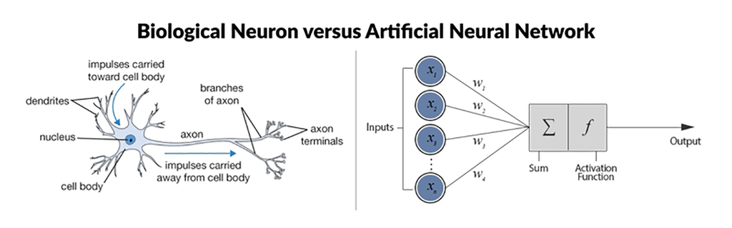

### Features

In order to make predictions, we use the following features:

```
1. Previous Changes in the Treasury Curve at the following tenors: 1 Month,
   3 Month, 1 Year, 2 Year, 5 Year, 7 Year, 10 Year, 30 Year

2. Changes in % of Federal Debt held by -

    a. Public,
    b. Foreign Goverments
    c. Federal Reserve

3. The Coporate Spread on Baa rated Debt Relative to the 10 Year
```

## Loading the Data

We get the data by webscapping using [pandas datareader](https://pandas-datareader.readthedocs.io/en/latest/remote_data.html), which extracts data from various Internet sources into a pandas DataFrame. In this case, we use `Federal Reserve Economic Data (FRED)` as the data source. With the datareader you can also use data sources such as `Quandl` or `World Bank’s World Development Indicators` and more, see [documentation](https://pandas-datareader.readthedocs.io/en/latest/remote_data.html#world-bank) for a full overview.

```python
tsy_tickers = ['DGS1MO', 'DGS3MO', 'DGS1', 'DGS2', 'DGS5', 'DGS7', 'DGS10', 'DGS30',
               # U.S. Treasury securities held by the Federal Reserve (Millions of Dollars)
               'TREAST',
               # Federal Debt Held by the Public (Millions of Dollars)
               'FYGFDPUN',
               # Federal Debt Held by Foreign and International Investors (Billions of Dollars)
               'FDHBFIN',
               # Federal Debt: Total Public Debt (Millions of Dollars)
               'GFDEBTN',
               'BAA10Y',  # Baa Corporate Bond Yield Relative to Yield on 10-Year
               ]
tsy_data = web.DataReader(tsy_tickers, 'fred').dropna(how='all').ffill()
tsy_data['FDHBFIN'] = tsy_data['FDHBFIN'] * 1000
tsy_data['GOV_PCT'] = tsy_data['TREAST'] / tsy_data['GFDEBTN']
tsy_data['HOM_PCT'] = tsy_data['FYGFDPUN'] / tsy_data['GFDEBTN']
tsy_data['FOR_PCT'] = tsy_data['FDHBFIN'] / tsy_data['GFDEBTN']
```

```python
return_period = 5

Y = tsy_data.loc[:, ['DGS1MO', 'DGS5', 'DGS30']].shift(-return_period)
Y.columns = [col+'_pred' for col in Y.columns]

X = tsy_data.loc[:, ['DGS1MO', 'DGS3MO', 'DGS1', 'DGS2', 'DGS5',
                     'DGS7', 'DGS10', 'DGS30', 'GOV_PCT', 'HOM_PCT', 'FOR_PCT', 'BAA10Y']]

dataset = pd.concat([Y, X], axis=1).dropna().iloc[::return_period, :]
Y = dataset.loc[:, Y.columns]
X = dataset.loc[:, X.columns]
```

```python
dataset.head(2)
```

| DATE | DGS1MO_pred | DGS5_pred | DGS30_pred | DGS1MO | DGS3MO | DGS1 | DGS2 | DGS5 | DGS7 | DGS10 | DGS30 | GOV_PCT | HOM_PCT | FOR_PCT | BAA10Y |
| --- | --- | --- | --- | --- | --- | --- | --- | --- | --- | --- | --- | --- | --- | --- | --- |
| 2017-10-01 | 1.03 | 1.97 | 2.91 | 0.96 | 1.06 | 1.31 | 1.47 | 1.92 | 2.16 | 2.33 | 2.86 | 0.120307 | 0.723334 | 0.303097 | 2.00 |
| 2017-10-06 | 0.97 | 1.95 | 2.82 | 1.03 | 1.07 | 1.35 | 1.54 | 1.97 | 2.20 | 2.37 | 2.91 | 0.120309 | 0.723334 | 0.303097 | 1.98 |

# EDA

## Descriptive Statistics

```python
dataset.describe()
```

|  | DGS1MO_pred | DGS5_pred | DGS30_pred | DGS1MO | DGS3MO | DGS1 | DGS2 | DGS5 | DGS7 | DGS10 | DGS30 | GOV_PCT | HOM_PCT | FOR_PCT | BAA10Y |
| --- | --- | --- | --- | --- | --- | --- | --- | --- | --- | --- | --- | --- | --- | --- | --- |
| count | 244.000000 | 244.000000 | 244.000000 | 244.000000 | 244.000000 | 244.000000 | 244.000000 | 244.000000 | 244.000000 | 244.000000 | 244.000000 | 244.000000 | 244.000000 | 244.000000 | 244.000000 |
| mean | 1.032377 | 1.666311 | 2.394713 | 1.027213 | 1.100205 | 1.298525 | 1.417951 | 1.662500 | 1.827664 | 1.950123 | 2.394139 | 0.138882 | 0.757736 | 0.277917 | 2.167131 |
| std | 0.928585 | 0.939431 | 0.621787 | 0.925452 | 0.936147 | 1.012216 | 1.028835 | 0.936491 | 0.863980 | 0.798616 | 0.621291 | 0.037104 | 0.024351 | 0.019934 | 0.407886 |
| min | 0.000000 | 0.210000 | 0.990000 | 0.000000 | 0.010000 | 0.040000 | 0.110000 | 0.210000 | 0.390000 | 0.540000 | 0.990000 | 0.091250 | 0.723334 | 0.250183 | 1.560000 |
| 25% | 0.070000 | 0.807500 | 1.920000 | 0.070000 | 0.090000 | 0.140000 | 0.200000 | 0.807500 | 1.145000 | 1.377500 | 1.920000 | 0.103322 | 0.733625 | 0.261594 | 1.907500 |
| 50% | 1.125000 | 1.680000 | 2.345000 | 1.095000 | 1.270000 | 1.550000 | 1.590000 | 1.680000 | 1.790000 | 1.865000 | 2.345000 | 0.120308 | 0.741858 | 0.285341 | 2.090000 |
| 75% | 1.902500 | 2.580000 | 3.000000 | 1.900000 | 1.970000 | 2.247500 | 2.452500 | 2.572500 | 2.692500 | 2.742500 | 3.000000 | 0.176797 | 0.782259 | 0.295093 | 2.272500 |
| max | 2.460000 | 3.340000 | 3.430000 | 2.460000 | 2.550000 | 3.180000 | 3.230000 | 3.340000 | 3.340000 | 3.250000 | 3.430000 | 0.191040 | 0.786267 | 0.304740 | 4.310000 |

## Data Visualization

```python
Y.plot();
```

[figure not shown]

```python
# density
dataset.plot(kind='density', subplots=True, layout=(4, 5),
             sharex=False, legend=True, fontsize=1, figsize=(12, 12));
```

[figure not shown]

```python
# Box and Whisker Plots
dataset.plot(kind='box', subplots=True, layout=(4, 5),
             sharex=False, sharey=False, figsize=(12, 12));
```

[figure not shown]

```python
# correlation
correlation = dataset.corr()
plt.figure(figsize=(15,15))
plt.title('Correlation Matrix')
sns.heatmap(correlation, vmax=1, square=True,annot=True,cmap='Greens')
```

[figure not shown]

From the correlation plot, we see that the 5 year yield seems to be negativly correlated with the changes in foreign goverment purchases.

## Data Preparation and Analysis

## Univariate Feature Selection

```python
bestfeatures = SelectKBest(k=5, score_func=f_regression)
for col in Y.columns:
    temp_Y = dataset[col]
    temp_X = dataset.loc[:, X.columns]
    fit = bestfeatures.fit(temp_X, temp_Y)
    dfscores = pd.DataFrame(fit.scores_)
    dfcolumns = pd.DataFrame(X.columns)
    # concat two dataframes for better visualization
    featureScores = pd.concat([dfcolumns, dfscores], axis=1)
    featureScores.columns = ['Specs', 'Score']  # naming the dataframe columns
    print(col)
    print(featureScores.nlargest(10, 'Score'))  # print 10 best features
    print('--------------')
    # As expected, based on the univariate feature selection, all the time series are
    # most dependent on the previous changes.
```

```
DGS1MO_pred
      Specs         Score
0    DGS1MO  28625.203750
1    DGS3MO  17752.558029
2      DGS1   1289.700508
3      DGS2    588.740303
8   GOV_PCT    548.332771
9   HOM_PCT    502.737636
10  FOR_PCT    328.571022
4      DGS5    325.489266
7     DGS30    286.366069
5      DGS7    282.963707
--------------
DGS5_pred
      Specs         Score
```

[output cut: 24 more lines]

# Evaluate Algorithms and Models

## Train Test Split and evaluation metrics

```python
# split out validation dataset for the end

validation_size = 0.2

# In case the data is not dependent on the time series, then train and test split randomly
seed = 7
X_train, X_validation, Y_train, Y_validation = train_test_split(
    X, Y, test_size=validation_size, random_state=seed)
```

We use the prebuilt scikit models to run a K fold analysis on our training data. We then train the model on the full training data and use it for prediction of the test data.

```python
# test options for regression
num_folds = 10
scoring = 'neg_mean_squared_error'
```

## Compare Models and Algorithms

```python
# initialize the models
models = []

models.append(('LR', LinearRegression()))
models.append(('Ridge', Ridge(alpha=.5)))
models.append(('LASSO', Lasso()))
models.append(('EN', ElasticNet()))

# NN
models.append(('MLP', MLPRegressor()))
```

```python
for name, model in models:
    kfold = KFold(n_splits=num_folds)
    # converted mean square error to positive. The lower the better
    cv_results = -1 * \
        cross_val_score(model, X_train, Y_train, cv=kfold, scoring=scoring)
    kfold_results.append(cv_results)
    names.append(name)
    # Finally we Train on the full period and test against validation
    res = model.fit(X_train, Y_train)
    validation_result = np.mean(
        np.square(res.predict(X_validation) - Y_validation))
    validation_results.append(validation_result)
    train_result = np.mean(np.square(res.predict(X_train) - Y_train))
    train_results.append(train_result)

    msg = "%s: \nAverage CV error: %s \nStd CV Error: (%s) \nTraining Error:\n%s \nTest Error:\n%s" % \
        (name, str(cv_results.mean()), str(cv_results.std()),
         str(train_result), str(validation_result))
    print(msg)
    print('----------')
```

```
LR:
Average CV error: 0.006996817524258349
Std CV Error: (0.003176321939282078)
Training Error:
DGS1MO_pred    0.001958
DGS5_pred      0.007873
DGS30_pred     0.006786
dtype: float64
Test Error:
DGS1MO_pred    0.012553
DGS5_pred      0.015530
DGS30_pred     0.019924
dtype: float64
----------
Ridge:
Average CV error: 0.006569128889432357
Std CV Error: (0.0030900409600404)
Training Error:
DGS1MO_pred    0.002089
DGS5_pred      0.008223
DGS30_pred     0.007222
dtype: float64
Test Error:
DGS1MO_pred    0.013228
DGS5_pred      0.015313
DGS30_pred     0.020974
dtype: float64
----------
LASSO:
Average CV error: 0.7163906375591571
Std CV Error: (0.07959162543521155)
Training Error:
DGS1MO_pred    0.842357
DGS5_pred      0.911970
DGS30_pred     0.382267
dtype: float64
Test Error:
DGS1MO_pred    0.931140
DGS5_pred      0.747680
DGS30_pred     0.396862
```

[output cut: 15 more lines]

```
----------
MLP:
Average CV error: 0.04533212973501507
Std CV Error: (0.05811002373893854)
Training Error:
DGS1MO_pred    0.020428
DGS5_pred      0.010733
DGS30_pred     0.012025
dtype: float64
Test Error:
DGS1MO_pred    0.026112
DGS5_pred      0.019028
DGS30_pred     0.024900
dtype: float64
----------
```

```python
# compare algorithms
fig = plt.figure(figsize=(10,6))
fig.suptitle('Algorithm Comparison: Kfold results')
ax = fig.add_subplot(111)
plt.boxplot(kfold_results)
ax.set_xticklabels(names)
fig.set_size_inches(10, 4);
```

[figure not shown]

```python
# compare algorithms
fig = plt.figure()

ind = np.arange(len(names))  # the x locations for the groups
width = 0.35  # the width of the bars

fig.suptitle('Algorithm Comparison')
ax = fig.add_subplot(111)
plt.bar(ind - width/2, [x.mean()
                           for x in train_results],  width=width, label='Train Error')
plt.bar(ind + width/2, [x.mean() for x in validation_results],
           width=width, label='Validation Error')
fig.set_size_inches(10,4)
plt.legend()
ax.set_xticks(ind)
ax.set_xticklabels(names);
```

[figure not shown]

# Model Tuning and Grid Search

```python
# Grid search : MLPRegressor
'''
hidden_layer_sizes : tuple, length = n_layers - 2, default (100,)
    The ith element represents the number of neurons in the ith
    hidden layer.
'''
param_grid = {'hidden_layer_sizes': [
    (20,), (50,), (20, 20), (20, 30, 20), (20, 20, 20)]}
model = MLPRegressor()
kfold = KFold(n_splits=num_folds)
grid = GridSearchCV(estimator=model, param_grid=param_grid,
                    scoring=scoring, cv=kfold)
grid_result = grid.fit(X_train, Y_train)
print("Best: %f using %s" % (grid_result.best_score_, grid_result.best_params_))
means = grid_result.cv_results_['mean_test_score']
stds = grid_result.cv_results_['std_test_score']
params = grid_result.cv_results_['params']
for mean, stdev, param in zip(means, stds, params):
    print("%f (%f) with: %r" % (mean, stdev, param))
```

```
Best: -0.029497 using {'hidden_layer_sizes': (20, 20)}
-0.089836 (0.034885) with: {'hidden_layer_sizes': (20,)}
-0.034006 (0.017975) with: {'hidden_layer_sizes': (50,)}
-0.029497 (0.013822) with: {'hidden_layer_sizes': (20, 20)}
-0.050323 (0.042765) with: {'hidden_layer_sizes': (20, 30, 20)}
-0.036734 (0.020921) with: {'hidden_layer_sizes': (20, 20, 20)}
```

# Finalise the Model

```python
# prepare model
model = MLPRegressor(hidden_layer_sizes=best_param)
model.fit(X_train, Y_train)
```

```
MLPRegressor(hidden_layer_sizes=(20, 20))
```

## Results and comparison of Regression and MLP

```python
# estimate accuracy on validation set
predictions = model.predict(X_validation)
mse_MLP = mean_squared_error(Y_validation, predictions)
r2_MLP = r2_score(Y_validation, predictions)

# prepare model
model_2 = LinearRegression()
model_2.fit(X_train, Y_train)
predictions_2 = model_2.predict(X_validation)

mse_OLS = mean_squared_error(Y_validation, predictions_2)
r2_OLS = r2_score(Y_validation, predictions_2)
print("MSE Regression = %f, MSE MLP = %f" % (mse_OLS, mse_MLP))
print("R2 Regression = %f, R2 MLP = %f" % (r2_OLS, r2_MLP))
```

```
MSE Regression = 0.016002, MSE MLP = 0.103113
R2 Regression = 0.971481, R2 MLP = 0.832514
```

### Predictions

```python
train_size = int(len(X) * (1-validation_size))
X_train, X_validation = X[0:train_size], X[train_size:len(X)]
Y_train, Y_validation = Y[0:train_size], Y[train_size:len(X)]

modelMLP = MLPRegressor(hidden_layer_sizes=(50,))
modelOLS = LinearRegression()
model_MLP = modelMLP.fit(X_train, Y_train)
model_OLS = modelOLS.fit(X_train, Y_train)

Y_predMLP = pd.DataFrame(model_MLP.predict(X_validation), index=Y_validation.index,
                         columns=Y_validation.columns)

Y_predOLS = pd.DataFrame(model_OLS.predict(X_validation), index=Y_validation.index,
                         columns=Y_validation.columns)
```

```python
# comparing the different tenors (the length of time remaining before a financial contract expires)
# we wanted to predict
pd.DataFrame({'Actual : 1m': Y_validation.loc[:, 'DGS1MO_pred'],
              'Prediction MLP 1m': Y_predMLP.loc[:, 'DGS1MO_pred'],
              'Prediction OLS 1m': Y_predOLS.loc[:, 'DGS1MO_pred']}).plot(figsize=(10, 5))

pd.DataFrame({'Actual : 5yr': Y_validation.loc[:, 'DGS5_pred'],
              'Prediction MLP 5yr': Y_predMLP.loc[:, 'DGS5_pred'],
              'Prediction OLS 5yr': Y_predOLS.loc[:, 'DGS5_pred']}).plot(figsize=(10, 5))

pd.DataFrame({'Actual : 30yr': Y_validation.loc[:, 'DGS30_pred'],
              'Prediction MLP 30yr': Y_predMLP.loc[:, 'DGS30_pred'],
              'Prediction OLS 30yr': Y_predOLS.loc[:, 'DGS30_pred']}).plot(figsize=(10, 5));
```

[figure not shown]